# Assignment 7

Krista Pipho, kp275

March 31, 2021

## PCA and CVA

Load in libraries

```r
library(tidyverse)
library(cowplot)
library(broom)
library(magrittr)
library(MASS)
library(ggforce)
```

### Problem 1:

Create a data frame from the wine data, and assign meaningful column names

```r
url <- "https://raw.githubusercontent.com/Bio723-class/example-datasets/master/wine.data"
wine <- read.csv(url, header = FALSE)

# Name the wine dataset columns
colnames(wine)<- c("Cultivar", "Alcohol", "Malic Acid", "Ash", "Alcalinity of ash", "Magnesium", "Total phenols", "Flavanoids", "Nonflavanoid phenols", "Proanthocyanins", "Color intensity", "Hue", "OD280/OD315 of diluted wines", "Proline")

glimpse(wine)
```

```
## Rows: 178
## Columns: 14
## $ Cultivar                       <int> 1, 1, 1, 1, 1, 1, 1, 1, 1, 1, 1, 1, ...
## $ Alcohol                        <dbl> 14.23, 13.20, 13.16, 14.37, 13.24, 1...
## $ `Malic Acid`                   <dbl> 1.71, 1.78, 2.36, 1.95, 2.59, 1.76, ...
## $ Ash                            <dbl> 2.43, 2.14, 2.67, 2.50, 2.87, 2.45, ...
## $ `Alcalinity of ash`            <dbl> 15.6, 11.2, 18.6, 16.8, 21.0, 15.2, ...
## $ Magnesium                      <int> 127, 100, 101, 113, 118, 112, 96, 12...
## $ `Total phenols`                <dbl> 2.80, 2.65, 2.80, 3.85, 2.80, 3.27, ...
## $ Flavanoids                     <dbl> 3.06, 2.76, 3.24, 3.49, 2.69, 3.39, ...
## $ `Nonflavanoid phenols`         <dbl> 0.28, 0.26, 0.30, 0.24, 0.39, 0.34, ...
## $ Proanthocyanins                <dbl> 2.29, 1.28, 2.81, 2.18, 1.82, 1.97, ...
## $ `Color intensity`              <dbl> 5.64, 4.38, 5.68, 7.80, 4.32, 6.75, ...
## $ Hue                            <dbl> 1.04, 1.05, 1.03, 0.86, 1.04, 1.05, ...
## $ `OD280/OD315 of diluted wines` <dbl> 3.92, 3.40, 3.17, 3.45, 2.93, 2.85, ...
## $ Proline                        <int> 1065, 1050, 1185, 1480, 735, 1450, 1...
```

### Problem 2:

Generate a derived data frame with the centered and scaled chemical attributes.

```r
measures.only <- wine %>% dplyr::select(-Cultivar)
cultivar.only <- wine %>% dplyr::select(Cultivar)
cultivar.only <- lapply(cultivar.only, as.factor)

#Center and scale te data
measures.only <- as.data.frame(scale(measures.only))
```

### Problem 3:

Using the centered-and-scaled attributes, carry out PCA of the wine data set. Generate a plots of the observations in the space of the first two PC axes. How much of the variation in the data is captured by PCs 1 and 2?

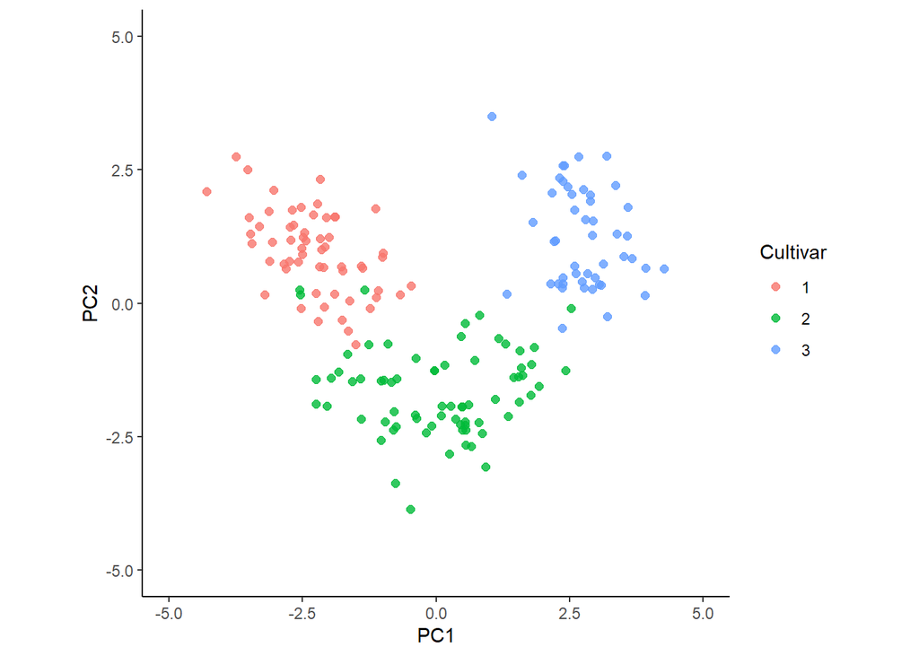

```r
# Run PCA analysis
measures.pca <- prcomp(measures.only, center=TRUE, retx=TRUE)

# Extract PCA scores from prcomp output
pca.scores.df <- as.data.frame(measures.pca$x)

# Define a coordinate system for the plot
coord.system <- coord_fixed(ratio=1, xlim=c(-5,5),ylim=c(-5,5))

# Add the cultivar lables back in
pca.scores.lab <- cbind(pca.scores.df,cultivar.only)

# Plot
pc1v2 <-
  pca.scores.lab %>%
  ggplot(aes(x = PC1, y= PC2, color = Cultivar)) +
  geom_point(size = 2, alpha = .8) +
  coord.system + theme_classic()

pc1v2
```

```r
# See a summary of how much varriance is explained by each PC
summary(measures.pca)
```

```
## Importance of components:
##                          PC1    PC2    PC3     PC4     PC5     PC6     PC7
## Standard deviation     2.169 1.5802 1.2025 0.95863 0.92370 0.80103 0.74231
## Proportion of Variance 0.362 0.1921 0.1112 0.07069 0.06563 0.04936 0.04239
## Cumulative Proportion  0.362 0.5541 0.6653 0.73599 0.80162 0.85098 0.89337
##                            PC8     PC9   PC10    PC11    PC12    PC13
## Standard deviation     0.59034 0.53748 0.5009 0.47517 0.41082 0.32152
## Proportion of Variance 0.02681 0.02222 0.0193 0.01737 0.01298 0.00795
## Cumulative Proportion  0.92018 0.94240 0.9617 0.97907 0.99205 1.00000
```

PC1 captures 36% of varriance in the data, while PC2 captures 19%.

### Problem 4:

Using the centered-and-scaled attributes, carry out CVA of the wine data set using the MASS::lda() function. How much of the between-group variance is captured by the respective canonical variates?

```r
# Adds cultivar lables back on
measures.lab <- cbind(measures.only,cultivar.only)

#
measures.lda <- lda(Cultivar ~ ., data = measures.lab)
measures.lda
```

```
## Call:
## lda(Cultivar ~ ., data = measures.lab)
##
## Prior probabilities of groups:
##         1         2         3
## 0.3314607 0.3988764 0.2696629
##
## Group means:
##      Alcohol `Malic Acid`        Ash `Alcalinity of ash`   Magnesium
## 1  0.9166093   -0.2915199  0.3246886          -0.7359212  0.46192317
## 2 -0.8892116   -0.3613424 -0.4437061           0.2225094 -0.36354162
## 3  0.1886265    0.8928122  0.2572190           0.5754413 -0.03004191
##   `Total phenols`  Flavanoids `Nonflavanoid phenols` Proanthocyanins
## 1      0.87090552  0.95419225            -0.57735640       0.5388633
## 2     -0.05790375  0.05163434             0.01452785       0.0688079
## 3     -0.98483874 -1.24923710             0.68817813      -0.7641311
##   `Color intensity`        Hue `OD280/OD315 of diluted wines`    Proline
## 1         0.2028288  0.4575567                      0.7691811  1.1711967
## 2        -0.8503999  0.4323908                      0.2446043 -0.7220731
## 3         1.0085728 -1.2019916                     -1.3072623 -0.3715295
##
## Coefficients of linear discriminants:
##                                       LD1          LD2
## Alcohol                        -0.3274906  0.707744750
## `Malic Acid`                    0.1846135  0.341153776
## Ash                            -0.1012536  0.643569825
## `Alcalinity of ash`             0.5169574 -0.488847900
## Magnesium                      -0.0309001 -0.006609312
## `Total phenols`                 0.3868085 -0.020160425
## Flavanoids                     -1.6592953 -0.491436530
## `Nonflavanoid phenols`         -0.1861596 -0.202977648
## Proanthocyanins                 0.0767491 -0.175764297
## `Color intensity`               0.8231206  0.587061123
## Hue                            -0.1869798 -0.346430951
## `OD280/OD315 of diluted wines` -0.8218561  0.036340126
## Proline                        -0.8474810  0.898426186
##
## Proportion of trace:
##    LD1    LD2
## 0.6875 0.3125
```

LD1 captures 69% of the between group variance, while LD2 captures 31%.

### Problem 5:

Generate a basic CVA plot for the wine data set

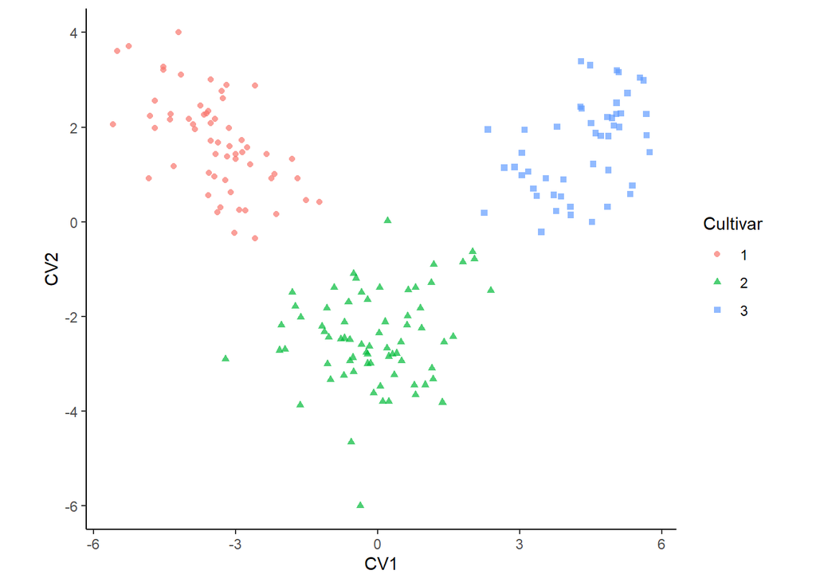

```r
measures.sub <-
  measures.only %>% as.matrix  # cast to matrix for calculations

# calculate CV scores
CVA.scores <- measures.sub %*% measures.lda$scaling

# create data frame with scores
measures.CV <- data.frame(CVA.scores)
measures.CV$Cultivar <- as.factor(wine$Cultivar)

measures.cva.plot <-
  ggplot(measures.CV, aes(x = LD1, y = LD2)) +
  geom_point(aes(color=Cultivar, shape=Cultivar), alpha=0.7) +
  labs(x = "CV1", y = "CV2") +
  coord_fixed(ratio=1) + theme_classic()

measures.cva.plot
```

### Problem 6:

Generate a CVA plot illustrating the 95% confidence regions for the group means.

```r
# Look up the chi squared values for .05 confidance
chi2 = qchisq(0.05,2, lower.tail=FALSE)

# Calculate the chi squared confidance regions
CIregions.mean.and.pop <-
  measures.CV %>%
  group_by(Cultivar) %>%
  summarize(CV1.mean = mean(LD1),
            CV2.mean = mean(LD2),
            mean.radii = sqrt(chi2/n()),
            popn.radii = sqrt(chi2))
```

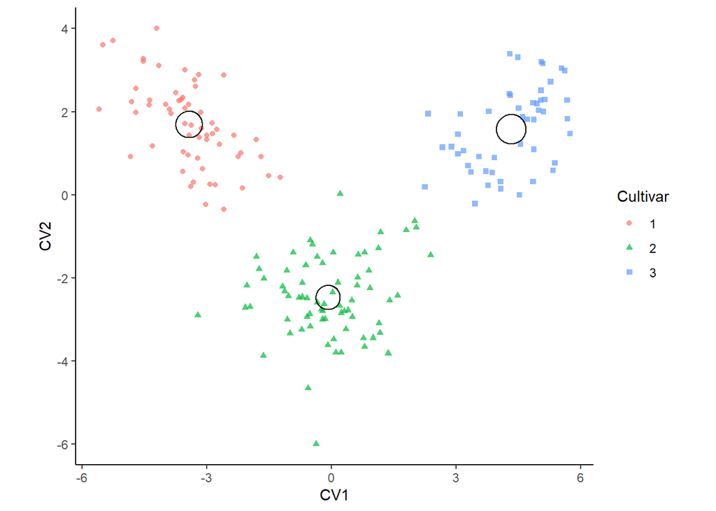

```r
# Plot the confidance regions as a for the mean and population
measures.cva.plot2 <-
  measures.cva.plot +
  geom_circle(data = CIregions.mean.and.pop,
              mapping = aes(x0 = CV1.mean, y0 = CV2.mean, r = mean.radii),
              inherit.aes = FALSE)

measures.cva.plot2
```

### Problem 7:

Generate another CVA plot illustrating the 95% tolerance regions for the group population distributions.

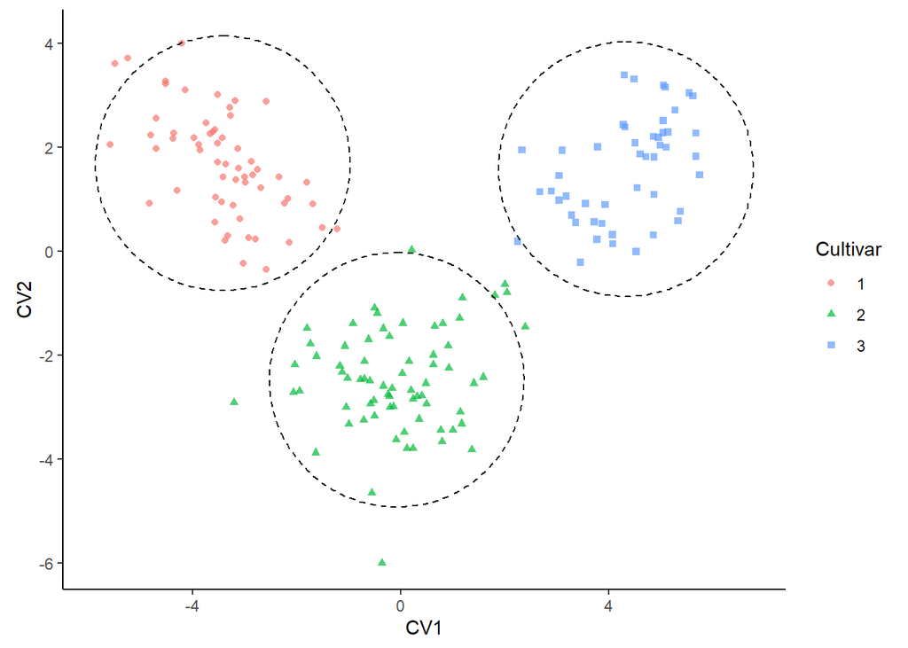

```r
measures.cva.plot3 <-
  measures.cva.plot +
  geom_circle(data = CIregions.mean.and.pop,
              mapping = aes(x0 = CV1.mean, y0 = CV2.mean, r = popn.radii),
              linetype = "dashed",
              inherit.aes = FALSE)

measures.cva.plot3
```

### Problem 8:

Comment on the similarities and differences between the PCA plot and CVA plot of the wine data.

The CVA plot has a very similar shape to the PCA plot, but seperates groups much more clearly. No 'stray' points are present within the 95% confidance interval of a different CVA group, but the edges of PCA groups are quite intermingled. If I needed to descriminate groups using this data I would deffinately choose the CVA over PCA for that analysis.